## Station Quiz - Week 10

Grading Rubric (per question):  
2 points if complete and correct  
1 point if incomplete or incorrect  
0 points if no attempt made

The following questions should be completed by yourself as an individual today. You are your own station. Thus you are the one who submits (commits/pushes) the answers to the quiz in their repo, i.e., the **designated submitter**. *You have until 11:59 PM Friday March 27, 2020 to complete these questions. Do not change anything in this file above the line.*

**#0** Pull this ipynb file from your respective **assignments_section_sp20** repo; either **assignments_section2_sp20** or **assignments_section3_sp20**. Copy it into your personal repo to begin answering the questions, but rename the file as station_quiz_week_10_Netid.R with your Netid. (GitHub)

**#1** Using Markdown syntax (not R syntax), make a bulleted list that has your first name in italic font in one bullet and your last name in bold font in another bullet. (Markdown)

- *Josh*
- **Janda**

**#2** Using the visualization below, describe what’s happening in the plot. (Data Visualization, Markdown)

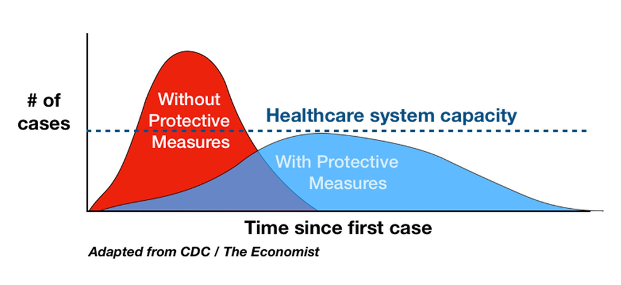

The plot is visualizing the number of cases against the time since the first case. Two curves are shown, the first curve being shown is the number of cases given no protective measures are taken. The second curve shown is the number of cases given protective measures are taken. There is a constant line showing the total healthcare system capacity. Taking protective measures, we are able to stay under the healthcare system capacity and therefore limit the number of deaths. Not taking protective measures, we will overwhelm the healthcare system capacity and lead to more deaths.

**#3** Import the powerlifting dataset (thanks to David Dalpiaz!) with the link https://uofi.box.com/shared/static/72tsz9guup6p31wc50zjw7y3lkvutqr5.csv. After importing, name the powerlifting data as **lift**. (R, Accessing and Importing Data)

```r
library(tidyverse)
library(knitr)
library(GGally)
lift = read_csv('https://uofi.box.com/shared/static/72tsz9guup6p31wc50zjw7y3lkvutqr5.csv')
colnames(lift) = tolower(colnames(lift))
```

**#4** Do the following data wrangling steps: - keep the following variables: Name, Sex, Event, Equipment, Age, AgeClass, BodyweightKg, WeightClassKg, Best3SquatKg, Best3BenchKg, Best3DeadliftKg, TotalKg, Wilks, IPFPoints - filter to keep female powerlifters in AgeClass 24-34 with SBD as the Event - remove NA values - rename the data object as **power**. (R, Accessing and Importing Data, Data Wrangling)

*There should be 54589 observations in the resulting* **power** *dataset.*

```r
power = lift %>%
  select(name, sex, event, equipment, age, ageclass, bodyweightkg, weightclasskg,
         best3squatkg, best3benchkg, best3deadliftkg, totalkg, wilks, ipfpoints) %>%
  filter(sex %in% c('F'),
         ageclass %in% c('24-34'),
         event %in% c('SBD')) %>%
  drop_na()
```

Total observations in **Power**: 54589

**#5** Create a new data set called **powerlbs** which is a copy of **power** but has converted the Kg variables of BodyweightKg, Best3SquatKg, Best3BenchKg, Best3DeadliftKg, and TotalKg to pounds (lb). Be sure to replace the “Kg” in the column names to be “Lb”. (R, Data Wrangling)

```r
kg_to_lbs = function(kg) {

  kg * 2.20462

}

powerlbs = power %>%
  mutate(bodyweightlb = kg_to_lbs(bodyweightkg),
         best3squatlb = kg_to_lbs(best3squatkg),
         best3benchlb = kg_to_lbs(best3benchkg),
         best3deadliftlb = kg_to_lbs(best3deadliftkg),
         totallb = kg_to_lbs(totalkg)) %>%
  select(-c(bodyweightkg, best3squatkg, best3benchkg,
            best3deadliftkg, totalkg))
```

**#6** Remove TotalLb due to multicollinearity. In addition, I am claiming that there are 10 (1 now) outliers in the data from **Problem 5**. Determine those outliers (using the three rules/identifiers in the notes) and remove them from the dataset. (R, Cluster Analysis)

```r
powerlbs = powerlbs %>% select(-totallb)
numeric_powerlbs = powerlbs %>% select_if(is.numeric) %>% select(-age)

##wilks
#3 sigma rule
mn_wilks = mean(numeric_powerlbs$wilks)
sg_wilks = sd(numeric_powerlbs$wilks)
tsr_wilks = which(abs(numeric_powerlbs$wilks-mn_wilks) > 3*sg_wilks)
#boxplot rule
q1 = as.vector(quantile(numeric_powerlbs$wilks, 1/4))
q3 = as.vector(quantile(numeric_powerlbs$wilks, 3/4))
iqr = as.vector(q3-q1)
lwr_wilks = which(numeric_powerlbs$wilks < q1-1.5*iqr)
upr_wilks = which(numeric_powerlbs$wilks > q3+1.5*iqr)
#hampel identifier
md_wilks = median(numeric_powerlbs$wilks)
sg_wilks = 1.4826*(median(abs(numeric_powerlbs$wilks - md_wilks)))
hi_wilks = which(abs(numeric_powerlbs$wilks - md_wilks) > 3*sg_wilks)

##ipfpoints
#3 sigma rule
mn_ipfpoints = mean(numeric_powerlbs$ipfpoints)
sg_ipfpoints = sd(numeric_powerlbs$ipfpoints)
tsr_ipfpoints = which(abs(numeric_powerlbs$ipfpoints-mn_ipfpoints) > 3*sg_ipfpoints)
#boxplot rule
q1 = as.vector(quantile(numeric_powerlbs$ipfpoints, 1/4))
q3 = as.vector(quantile(numeric_powerlbs$ipfpoints, 3/4))
iqr = as.vector(q3-q1)
lwr_ipfpoints = which(numeric_powerlbs$ipfpoints < q1-1.5*iqr)
upr_ipfpoints = which(numeric_powerlbs$ipfpoints > q3+1.5*iqr)
#hampel identifier
md_ipfpoints = median(numeric_powerlbs$ipfpoints)
sg_ipfpoints = 1.4826*(median(abs(numeric_powerlbs$ipfpoints - md_ipfpoints)))
hi_ipfpoints = which(abs(numeric_powerlbs$ipfpoints - md_ipfpoints) > 3*sg_ipfpoints)

##bodyweightlb
#3 sigma rule
mn_bodyweightlb = mean(numeric_powerlbs$bodyweightlb)
sg_bodyweightlb = sd(numeric_powerlbs$bodyweightlb)
tsr_bodyweightlb = which(abs(numeric_powerlbs$bodyweightlb-mn_bodyweightlb) > 3*sg_bodyweightlb)
#boxplot rule
q1 = as.vector(quantile(numeric_powerlbs$bodyweightlb, 1/4))
q3 = as.vector(quantile(numeric_powerlbs$bodyweightlb, 3/4))
iqr = as.vector(q3-q1)
lwr_bodyweightlb = which(numeric_powerlbs$bodyweightlb < q1-1.5*iqr)
upr_bodyweightlb = which(numeric_powerlbs$bodyweightlb > q3+1.5*iqr)
#hampel identifier
md_bodyweightlb = median(numeric_powerlbs$bodyweightlb)
sg_bodyweightlb = 1.4826*(median(abs(numeric_powerlbs$bodyweightlb - md_bodyweightlb)))
hi_bodyweightlb = which(abs(numeric_powerlbs$bodyweightlb - md_bodyweightlb) > 3*sg_bodyweightlb)

##best3squatlb
#3 sigma rule
mn_best3squatlb = mean(numeric_powerlbs$best3squatlb)
sg_best3squatlb = sd(numeric_powerlbs$best3squatlb)
tsr_best3squatlb = which(abs(numeric_powerlbs$best3squatlb-mn_best3squatlb) > 3*sg_best3squatlb)
#boxplot rule
q1 = as.vector(quantile(numeric_powerlbs$best3squatlb, 1/4))
q3 = as.vector(quantile(numeric_powerlbs$best3squatlb, 3/4))
iqr = as.vector(q3-q1)
lwr_best3squatlb = which(numeric_powerlbs$best3squatlb < q1-1.5*iqr)
upr_best3squatlb = which(numeric_powerlbs$best3squatlb > q3+1.5*iqr)
#hampel identifier
md_best3squatlb = median(numeric_powerlbs$best3squatlb)
sg_best3squatlb = 1.4826*(median(abs(numeric_powerlbs$best3squatlb - md_best3squatlb)))
hi_best3squatlb = which(abs(numeric_powerlbs$best3squatlb - md_best3squatlb) > 3*sg_best3squatlb)

##best3benchlb
#3 sigma rule
mn_best3benchlb = mean(numeric_powerlbs$best3benchlb)
sg_best3benchlb = sd(numeric_powerlbs$best3benchlb)
tsr_best3benchlb = which(abs(numeric_powerlbs$best3benchlb-mn_best3benchlb) > 3*sg_best3benchlb)
#boxplot rule
q1 = as.vector(quantile(numeric_powerlbs$best3benchlb, 1/4))
q3 = as.vector(quantile(numeric_powerlbs$best3benchlb, 3/4))
iqr = as.vector(q3-q1)
lwr_best3benchlb = which(numeric_powerlbs$best3benchlb < q1-1.5*iqr)
upr_best3benchlb = which(numeric_powerlbs$best3benchlb > q3+1.5*iqr)
#hampel identifier
md_best3benchlb = median(numeric_powerlbs$best3benchlb)
sg_best3benchlb = 1.4826*(median(abs(numeric_powerlbs$best3benchlb - md_best3benchlb)))
hi_best3benchlb = which(abs(numeric_powerlbs$best3benchlb - md_best3benchlb) > 3*sg_best3benchlb)

##best3deadliftlb
#3 sigma rule
mn_best3deadliftlb = mean(numeric_powerlbs$best3deadliftlb)
sg_best3deadliftlb = sd(numeric_powerlbs$best3deadliftlb)
tsr_best3deadliftlb = which(abs(numeric_powerlbs$best3deadliftlb-mn_best3deadliftlb) > 3*sg_best3deadliftlb)
#boxplot rule
q1 = as.vector(quantile(numeric_powerlbs$best3deadliftlb, 1/4))
q3 = as.vector(quantile(numeric_powerlbs$best3deadliftlb, 3/4))
iqr = as.vector(q3-q1)
lwr_best3deadliftlb = which(numeric_powerlbs$best3deadliftlb < q1-1.5*iqr)
upr_best3deadliftlb = which(numeric_powerlbs$best3deadliftlb > q3+1.5*iqr)
#hampel identifier
md_best3deadliftlb = median(numeric_powerlbs$best3deadliftlb)
sg_best3deadliftlb = 1.4826*(median(abs(numeric_powerlbs$best3deadliftlb - md_best3deadliftlb)))
hi_best3deadliftlb = which(abs(numeric_powerlbs$best3deadliftlb - md_best3deadliftlb) > 3*sg_best3deadliftlb)

outliers = data.frame(Wilks = c(length(tsr_wilks), length(lwr_wilks), length(upr_wilks), length(hi_wilks)),
  IpfPoints = c(length(tsr_ipfpoints), length(lwr_ipfpoints), length(upr_ipfpoints), length(hi_ipfpoints)),
  BodyWeightLb = c(length(tsr_bodyweightlb), length(lwr_bodyweightlb), length(upr_bodyweightlb), length(hi_bodyweightlb)),
  Best3SquatLb = c(length(tsr_best3squatlb), length(lwr_best3squatlb), length(upr_best3squatlb), length(hi_best3squatlb)),
  Best3BenchLb = c(length(tsr_best3benchlb), length(lwr_best3benchlb), length(upr_best3benchlb), length(hi_best3benchlb)),
  Best3DeadliftLb = c(length(tsr_best3deadliftlb), length(lwr_best3deadliftlb), length(upr_best3deadliftlb), length(hi_best3deadliftlb)))
row.names(outliers) = c('3Sigma', 'LwrBoxPlot', 'UprBoxPlot', 'Hampel')
kable(outliers)
```

|  | Wilks | IpfPoints | BodyWeightLb | Best3SquatLb | Best3BenchLb | Best3DeadliftLb |
| --- | --- | --- | --- | --- | --- | --- |
| 3Sigma | 399 | 277 | 1049 | 613 | 906 | 279 |
| LwrBoxPlot | 15 | 80 | 0 | 26 | 0 | 101 |
| UprBoxPlot | 1195 | 577 | 2792 | 1720 | 2092 | 707 |
| Hampel | 892 | 365 | 2249 | 1296 | 2092 | 412 |

Looking at the output above, we see that all variables have a good amount of observations that can be considered outliers. I do not want to look at the lower box plot observations, as there are very few that can be considered outliers. I will drop any outliers that intersect between all variables.

```r
Reduce(intersect, list(tsr_wilks, upr_wilks, hi_wilks,
                       tsr_ipfpoints, upr_ipfpoints, hi_ipfpoints,
                       tsr_bodyweightlb, upr_bodyweightlb, hi_bodyweightlb,
                       tsr_best3squatlb, upr_best3squatlb, hi_best3squatlb,
                       tsr_best3benchlb, upr_best3benchlb, hi_best3benchlb,
                       tsr_best3deadliftlb, upr_best3deadliftlb, hi_best3deadliftlb))
```

```
## [1] 11005
```

We see that observation **11005** is considered an outlier between all variables. Let’s remove this observation.

```r
powerlbs[11003:11007, ]
```

```
## # A tibble: 5 x 13
##   name  sex   event equipment   age ageclass weightclasskg wilks ipfpoints
##   <chr> <chr> <chr> <chr>     <dbl> <chr>    <chr>         <dbl>     <dbl>
## 1 Gill~ F     SBD   Wraps        29 24-34    60             425.      677.
## 2 Krys~ F     SBD   Wraps        33 24-34    67.5           418.      677.
## 3 Apri~ F     SBD   Wraps        29 24-34    90+            613.      996.
## 4 Heat~ F     SBD   Multi-ply    34 24-34    90+            423.      532.
## 5 Megh~ F     SBD   Wraps        29 24-34    60             443.      704.
## # ... with 4 more variables: bodyweightlb <dbl>, best3squatlb <dbl>,
## #   best3benchlb <dbl>, best3deadliftlb <dbl>
```

```r
powerlbs_ol_rm = powerlbs %>% slice(-11005) # removes observation #11005 (April Mathis)

powerlbs_ol_rm[11003:11007, ]
```

```
## # A tibble: 5 x 13
##   name  sex   event equipment   age ageclass weightclasskg wilks ipfpoints
##   <chr> <chr> <chr> <chr>     <dbl> <chr>    <chr>         <dbl>     <dbl>
## 1 Gill~ F     SBD   Wraps        29 24-34    60             425.      677.
## 2 Krys~ F     SBD   Wraps        33 24-34    67.5           418.      677.
## 3 Heat~ F     SBD   Multi-ply    34 24-34    90+            423.      532.
## 4 Megh~ F     SBD   Wraps        29 24-34    60             443.      704.
## 5 Megh~ F     SBD   Raw          33 24-34    48             249.      353.
## # ... with 4 more variables: bodyweightlb <dbl>, best3squatlb <dbl>,
## #   best3benchlb <dbl>, best3deadliftlb <dbl>
```

We see that April Mathis is now removed.

**#7** Use the `set.seed` random number generator (where the seed number is 448) to select a random sample size of 100 observations of the resulting dataset (after removing the 10 outliers) in **Problem 6**. Then, standardize the continuous variables of this random subset. (R, Data Descriptives, Cluster Analysis)

```r
set.seed(448)

power_sample = powerlbs_ol_rm %>% sample_n(100)
power_sample_num = power_sample %>% select_if(is.numeric) %>% select(-age)

power_sample_scaled = as.data.frame(scale(power_sample_num))
```

**#8** Use k-means clustering and select 2 clusters. Show the cluster attributes in the form of both

1. a scatter plot matrix of the 6 continuous variables
2. tables showing the mean and median of these 6 variables.

(R, Cluster Analysis, Data Visualization, Data Descriptives, Markdown)

```r
k_cluster = kmeans(power_sample_scaled, centers=2)$cluster

power_k = power_sample_scaled %>% mutate(k_cluster)
```

Cluster Sizes:

- Cluster 1: 55
- Cluster 2: 45

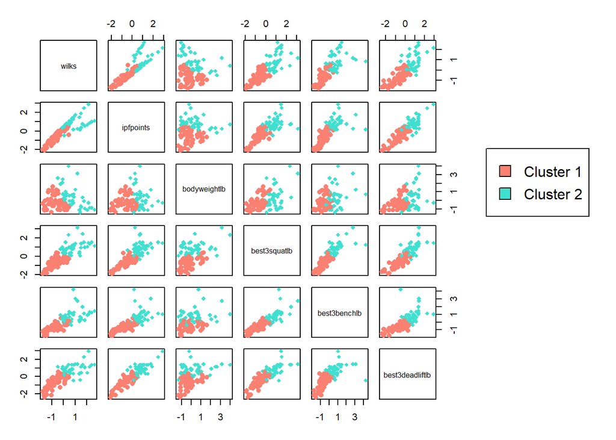

```r
group = NA
group[power_k$k_cluster == 1] = 1
group[power_k$k_cluster == 2] = 2

pairs(power_k[1:6],
      pch = c(16, 18)[group],
      col = c('salmon', 'turquoise')[group],
      oma = c(3, 3, 3, 15))
par(xpd=TRUE)
legend(.85, .7, fill = c('salmon', 'turquoise'), legend = c('Cluster 1', 'Cluster 2'), ncol=1)
```

```r
summarise(group_by(power_k, k_cluster),
          clustersize = length(wilks),
          mean_wilks = mean(wilks), median_wilks = median(wilks),
          mean_wilks = mean(ipfpoints), median_ipfpoints = median(ipfpoints),
          mean_bodyweightlb = mean(bodyweightlb), median_bodyweightlb = median(bodyweightlb),
          mean_best3squatlb = mean(best3squatlb), median_best3squatlb = median(best3squatlb),
          mean_best3benchlb = mean(best3benchlb), median_best3benchlb = median(best3benchlb),
          mean_best3deadliftlb = mean(best3deadliftlb), median_best3deadliftlb = median(best3deadliftlb)) -> k_means_summary

k_means_summary = as.data.frame(k_means_summary) %>% select(-k_cluster)
k_means_summary = as.data.frame(t(k_means_summary))
colnames(k_means_summary) = c('Cluster1', 'Cluster2')
kable(k_means_summary)
```

|  | Cluster1 | Cluster2 |
| --- | --- | --- |
| clustersize | 55.0000000 | 45.0000000 |
| mean_wilks | -0.6673128 | 0.8156045 |
| median_wilks | -0.6905420 | 0.6607065 |
| median_ipfpoints | -0.6131372 | 0.7366058 |
| mean_bodyweightlb | -0.2391342 | 0.2922752 |
| median_bodyweightlb | -0.3980203 | 0.0413952 |
| mean_best3squatlb | -0.7122203 | 0.8704915 |
| median_best3squatlb | -0.6492550 | 0.8127497 |
| mean_best3benchlb | -0.6509694 | 0.7956292 |
| median_best3benchlb | -0.6765533 | 0.6124061 |
| mean_best3deadliftlb | -0.6631935 | 0.8105698 |
| median_best3deadliftlb | -0.5225431 | 0.7690825 |

**#9** Use hierarchical clustering with single linkage and select 2 clusters. Show the cluster attributes in the form of both

1. a scatter plot matrix of the 6 continuous variables
2. tables showing the mean and median of these 6 variables.

(R, Cluster Analysis, Data Visualization, Data Descriptives, Markdown)

```r
dist_mtx =  dist(power_sample_scaled, method = "euclidean")
power_hclust =  hclust(dist_mtx, method="single")

hcls = cutree(power_hclust, k = 2)

power_hcls = power_sample_scaled %>% mutate(hcls)
```

Cluster Sizes:

- Cluster 1: 99
- Cluster 2: 1

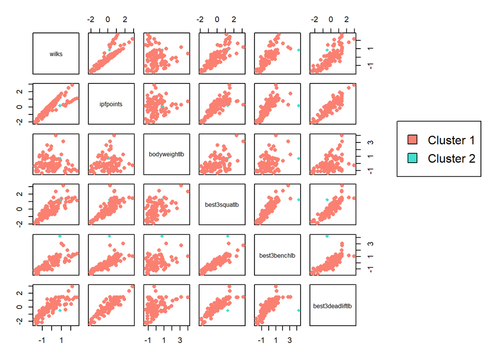

```r
group = NA
group[power_hcls$hcls == 1] = 1
group[power_hcls$hcls == 2] = 2

pairs(power_hcls[1:6],
      pch = c(16, 18)[group],
      col = c('salmon', 'turquoise')[group],
      oma = c(3, 3, 3, 15))
par(xpd=TRUE)
legend(.85, .7, fill = c('salmon', 'turquoise'), legend = c('Cluster 1', 'Cluster 2'), ncol=1)
```

```r
summarise(group_by(power_hcls, hcls),
          clustersize = length(wilks),
          mean_wilks = mean(wilks), median_wilks = median(wilks),
          mean_wilks = mean(ipfpoints), median_ipfpoints = median(ipfpoints),
          mean_bodyweightlb = mean(bodyweightlb), median_bodyweightlb = median(bodyweightlb),
          mean_best3squatlb = mean(best3squatlb), median_best3squatlb = median(best3squatlb),
          mean_best3benchlb = mean(best3benchlb), median_best3benchlb = median(best3benchlb),
          mean_best3deadliftlb = mean(best3deadliftlb), median_best3deadliftlb = median(best3deadliftlb)) -> hcls_summary

hcls_summary = as.data.frame(hcls_summary) %>% select(-hcls)
hcls_summary = as.data.frame(t(hcls_summary))
colnames(hcls_summary) = c('Cluster1', 'Cluster2')
kable(hcls_summary)
```

|  | Cluster1 | Cluster2 |
| --- | --- | --- |
| clustersize | 99.0000000 | 1.0000000 |
| mean_wilks | -0.0017873 | 0.1769439 |
| median_wilks | -0.0485425 | 0.8583965 |
| median_ipfpoints | 0.1310129 | 0.1769439 |
| mean_bodyweightlb | -0.0074458 | 0.7371365 |
| median_bodyweightlb | -0.2515485 | 0.7371365 |
| mean_best3squatlb | -0.0129084 | 1.2779330 |
| median_best3squatlb | -0.1840717 | 1.2779330 |
| mean_best3benchlb | -0.0430753 | 4.2644574 |
| median_best3benchlb | -0.1394869 | 4.2644574 |
| mean_best3deadliftlb | 0.0045108 | -0.4465651 |
| median_best3deadliftlb | 0.0093027 | -0.4465651 |

**#10** Are the clusters the same for hierarchical clustering and k-means clustering? Describe the cluster attributes in the 2 clusters and any interesting features/attributes among the clusters - for both hierarchical and k-means clustering. (R, Cluster Analysis, Data Visualization, Data Descriptives, Markdown)

Looking at the outputs above, the clusters are definitely not the same for hierarchical clustering and k-means clustering. These methods are two different algorithms, so it makes sense to not get the same cluster outputs.

**#00** The **designated submitter** should commit and push the file to their repo with the commit message “All Done”.